# POLISCI 9590 - Lab1: Data Management and Recoding Variables

William Poirier

2025-09-17

## 00. What we’ll be doing:

0. (Brief) Review of R and RMD;
1. Import Data;
2. Explore Data;
3. Cleaning Data;
4. Exercises.

## 0. R and RMD

Open lab 0.

## 1. Import Data

You have seen this in many forms:

1. Data from packages can be called directly when the package is loaded.
2. It can be imported from files on your computer via `rio::import()`, or other functions depending on the file format.

```r
library(tidyverse)
data(Arrests, package="carData")
Arrests <- as_tibble(Arrests)
```

## 2. Explore Data

### 2.1 The **pipe** `|>`/`%>%`

- The pipe operator prevents us from having to save intermediate states of the data when doing multiple operations.
- It takes whatever comes before and plugs it (pipes it) into whatever comes after.
- MAC: shift + cmd + m
- PC: shift + ctrl + m

```r
# Instead of doing

## Select some columns
dat <- select(Arrests,colour,age,sex)
## Add a new variable made from an existing one
dat$male <- ifelse(dat$sex=="Male",1,0)
## Summarizing the frequencies
table(dat$colour[dat$male==1])
```

```
##
## Black White
##  1216  3567
```

```r
# You can do
dat <- Arrests |>
  select(colour,age,sex) |>
  mutate(male=ifelse(sex=="Male",1,0)) |>
  filter(male==1) |>
  group_by(colour) |>
  summarise(n=n())
dat
```

```
## # A tibble: 2 × 2
##   colour     n
##   <fct>  <int>
## 1 Black   1216
## 2 White   3567
```

### 2.2 Basic `dplyr` verbs

- `select()`: to select columns;
- `filter()`: to filter data according to some condition;
- `mutate()`: create a variable or modify an existing one;
- `rename()`: change the label/name of an existing variable;
- `group_by()`: group the data according to some variable(s) such that the following operations are made “group-wise”;
- `summarise()`: reduce the data to some statistics in accordance with groups if previously specified;
- `arrange()`: order the rows according to the values of a particular variable;
- `slice()`: keep a set of rows;
- `slice_head()`: keep the first n rows;
- `slice_tail()`: keep the last n rows;
- `na.omit()`: removes any row for which one of the available columns contains a NA;
- `drop_na()`: removes any row for which NA appears in the specified column.

### 2.3 Examples

1. What is the release rate for employed `Black` and `White`?

```r
table(Arrests$released)
```

```
##
##   No  Yes
##  892 4334
```

```r
head(Arrests$employed=="Yes",n=10)
```

```
##  [1]  TRUE  TRUE  TRUE  TRUE  TRUE  TRUE FALSE  TRUE  TRUE  TRUE
```

```r
c("Yes","No","Maybe")=="Yes"
```

```
## [1]  TRUE FALSE FALSE
```

```r
Arrests |>
  mutate(released_bin=ifelse(released=="Yes",1,0)) |>
  filter(employed=="Yes") |>
  group_by(colour) |>
  summarise(average=mean(released_bin))
```

```
## # A tibble: 2 × 2
##   colour average
##   <fct>    <dbl>
## 1 Black    0.797
## 2 White    0.888
```

2. Does it differ by sex?

```r
Arrests |>
  mutate(released_bin=ifelse(released=="Yes",1,0)) |>
  filter(employed=="Yes") |>
  group_by(colour,sex,citizen) |>
  summarise(average=mean(released_bin))
```

```
## # A tibble: 8 × 4
## # Groups:   colour, sex [4]
##   colour sex    citizen average
##   <fct>  <fct>  <fct>     <dbl>
## 1 Black  Female No        1
## 2 Black  Female Yes       0.857
## 3 Black  Male   No        0.716
## 4 Black  Male   Yes       0.820
## 5 White  Female No        1
## 6 White  Female Yes       0.932
## 7 White  Male   No        0.818
## 8 White  Male   Yes       0.891
```

3. What is the top 2 and bottom 2 years for the number of arrest?

```r
arrestFreqYear <- Arrests |>
  group_by(year) |>
  summarise(n=n()) |>
  arrange(-n)

arrestFreqYear |> slice_head(n=2)
```

```
## # A tibble: 2 × 2
##    year     n
##   <int> <int>
## 1  2000  1270
## 2  2001  1211
```

```r
arrestFreqYear |> slice_tail(n=2)
```

```
## # A tibble: 2 × 2
##    year     n
##   <int> <int>
## 1  1997   492
## 2  2002   277
```

4. From the `UN` dataset found in the `carData` package, extract the following variables (`country`,`ppgdp`,`lifeExpF`,`pctUrban`,`infantMortality`) and find the top 5 countries for `infantMortality` among full information countries.

```r
data(UN, package="carData")
UN <- as_tibble(UN,rownames="country")

UN |>
  select(country,ppgdp,lifeExpF,pctUrban,infantMortality) |>
  na.omit() |>
  arrange(-infantMortality) |>
  slice_head(n=5)
```

```
## # A tibble: 5 × 5
##   country                          ppgdp lifeExpF pctUrban infantMortality
##   <chr>                            <dbl>    <dbl>    <dbl>           <dbl>
## 1 Afghanistan                       499      49.5       23            125.
## 2 Chad                              727.     51.6       28            124.
## 3 Guinea-Bissau                     539.     50.4       30            110.
## 4 Democratic Republic of the Congo  201.     50.6       36            109.
## 5 Sierra Leone                      352.     48.9       39            103.
```

## 3. Cleaning Data

### 3.1 Renaming Variables

Sometimes, datasets ship with nonsensical variable names. You have two options:

1. Use `rename()` from `dplyr`;
2. Use `names()`.

```r
data(CES11, package="carData")

# Option 1
CleanCES <- CES11 |> rename(relImportant = importance)
names(CleanCES)
```

```
## [1] "id"           "province"     "population"   "weight"       "gender"
## [6] "abortion"     "relImportant" "education"    "urban"
```

```r
# Option 2
CleanCES <- CES11
names(CleanCES)
```

```
## [1] "id"         "province"   "population" "weight"     "gender"
## [6] "abortion"   "importance" "education"  "urban"
```

```r
names(CleanCES)[7] <- "relImportant"
names(CleanCES)
```

```
## [1] "id"           "province"     "population"   "weight"       "gender"
## [6] "abortion"     "relImportant" "education"    "urban"
```

### 3.2 Creating Variables

This is different from renaming variables in that you create a new column in the dataset. This is done to:

1. Change the strucutre of an existing variable;
2. Create new variables from existing ones.

There are two ways to create new variables:

1. Using `mutate()` from `dplyr`;
2. Using `$` and assigning the new values.

Here are a few functions that come in handy in a `mutate()` call when you want to change the structure of a variable:

- `ifelse()`;
- `case_when()`.

Let’s see some examples.

1. Create a dummy variable (binary 0,1) for sex:

```r
# Base R
CleanCES$female <- 0
CleanCES$female[CleanCES$gender=="Female"] <- 1

# dplyr
CleanCES <- CleanCES |>
  mutate(female = ifelse(gender=="Female",1,0))
```

**Note that you must always be carefull with NAs!**

2. Let’s introduce some at random and see what happens when using the code above:

```r
# Adding fake NAs for the example
set.seed(122)
fakeNA <- sample(c(T,F),size=nrow(CES11),replace=T,prob = c(.01,.99))
tmp <- CES11
tmp$gender[fakeNA] <- NA

# See if it worked
table(tmp$gender, useNA = "ifany")
```

```
##
## Female   Male   <NA>
##   1234    979     18
```

```r
# Another way
sum(is.na(tmp$gender))
```

```
## [1] 18
```

```r
# Let's recode using ifelse
Clean_tmp <- tmp |>
  mutate(female = ifelse(gender=="Female",1,0))
table(Clean_tmp$female, useNA = "ifany")
```

```
##
##    0    1 <NA>
##  979 1234   18
```

```r
# Let's recode using base R
Clean_tmp$female <- 0
Clean_tmp$female[Clean_tmp$gender=="Female"] <- 1
table(Clean_tmp$female, useNA = "ifany")
```

```
##
##    0    1
##  997 1234
```

3. Create an education variable with three levels:

```r
table(CleanCES$education, useNA = "ifany")
```

```
##
## bachelors   college    higher        HS    lessHS    somePS
##       506       491       246       467       267       254
```

```r
CleanCES <- CleanCES |>
  mutate(educ_3l = case_when(education %in% c("bachelors","college","higher") ~ "uni",
                             education %in% c("HS","somePS") ~ "hs",
                             education == "lessHS" ~ "no hs"))

table(CleanCES$educ_3l, useNA = "ifany")
```

```
##
##    hs no hs   uni
##   721   267  1243
```

### 3.3 Factors

Remember how I told you there were 4 main data types?

1. **Numeric**: The real numbers (-1,-.5,0,.5,1,3.141593…)
2. **Character**: Text
3. **Logical**: `TRUE` (1) or `FALSE` (0) – abbreviate using `T` and `F`
4. **Integer**: …, -3, -2, -1, 0, 1, 2, 3, …

Well there’s a fifth one that you need to know about: **factors**.

Factors place a numerical value on characters. Very usefull when computers use to have limited RAM, but it’s not use for this anymore. Today we use it to impose a new ordering to character variables, instead of them being oredered alphabetically.

See for example the order of the `levels` of our `educ_3l` variable:

```r
table(CleanCES$educ_3l)
```

```
##
##    hs no hs   uni
##   721   267  1243
```

This means that if I want to produce a graph out of the data, it’s going to be in that order.

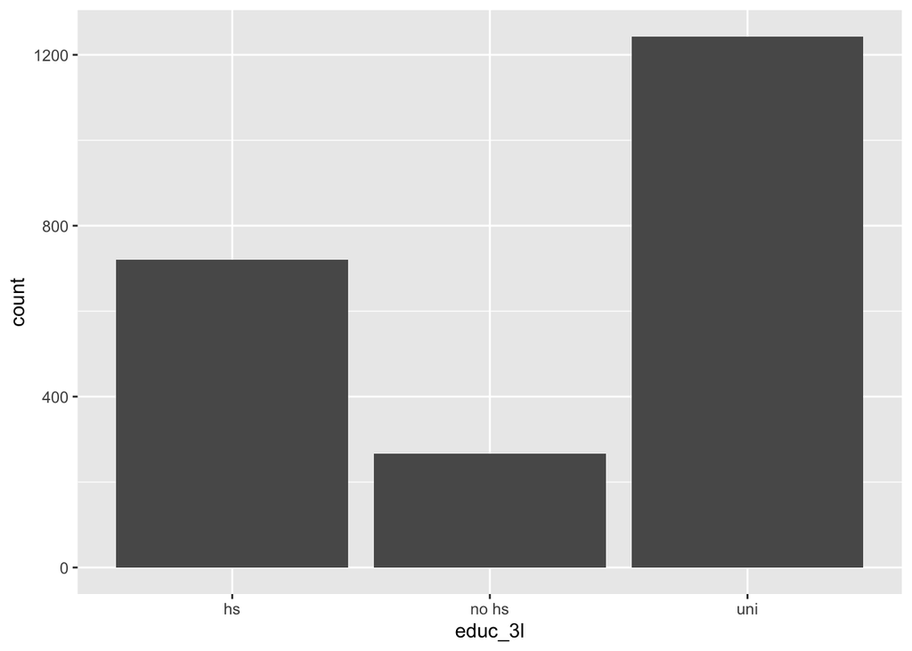

```r
ggplot(CleanCES,aes(x=educ_3l)) +
  geom_bar()
```

To prevent this, we can use the `factor` function:

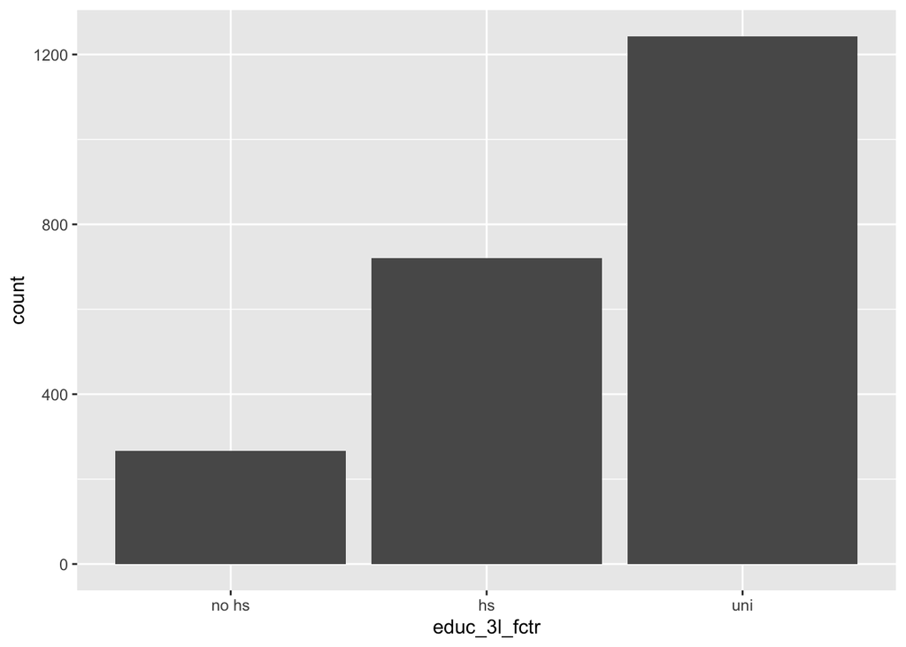

```r
CleanCES <- CleanCES |>
  mutate(educ_3l_fctr = factor(educ_3l, levels=c("no hs", "hs", "uni")))

ggplot(CleanCES,aes(x=educ_3l_fctr)) +
  geom_bar()
```

## 4. Exercises

1. What is the `fertility` rate and `ppgdp` of the 4 countries with the highest female life expectancy (`lifeExpF`)? Make sure you are using no country where `region` is missing.

```r
UN |>
  drop_na(region) |>
  arrange(-lifeExpF) |>
  select(country,fertility,ppgdp,lifeExpF) |>
  slice_head(n=4)
```

```
## # A tibble: 4 × 4
##   country   fertility  ppgdp lifeExpF
##   <chr>         <dbl>  <dbl>    <dbl>
## 1 Japan          1.42 43141.     87.1
## 2 Hong Kong      1.14 31824.     86.4
## 3 France         1.99 39546.     84.9
## 4 Spain          1.50 30543.     84.8
```

2. What is the `fertility` rate and `ppgdp` of the 2 most urbanized country for each `region`? Make sure you are using no country where `region` is missing.
3. Create a variable called `fertility1000`, which is the result of this operation `fertility*1000-infantMortality`. What is the highest country on `fertility1000` in each region?